# Basics IV: Data Visualizations Using ggplot

## Step 4: Customize a plot layer.

The real fun of ggplot is the ability to customize your plots - to make them look *exactly* how you want. Struggling to decide between a career as a data scientist or as an artist? Making plots with ggplot lets you do both!

Different geoms can take different arguments, called ‘aesthetics’, that can be customiezed. Some common ones are *size*, *color*, *shape*, and *fill*.

The help page for each geom function tells you what aesthetics are available for it.

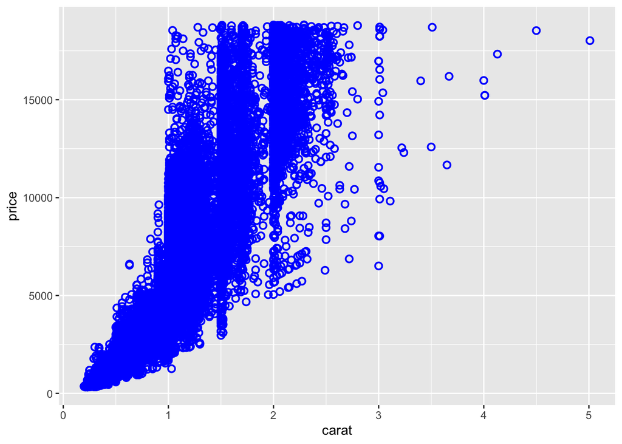

```r
ggplot(data = diamonds, aes(x = carat, y = price)) +
  geom_point(size = 2,
             color = "blue",
             shape = 1,
             stroke = 1)
```

## Understanding aes()

In ggplot, we can specify aesthetics in 2 different ways:

### Outside aes()

This is what we do when we want some aesthetic property of our graph to be constant. The previous example used this method, making *all* of the points blue circles at are size 2

### Inside aes()

This is what we do when we want some property of the graph to vary based on some variable in our data. For example, if we want the color of the points to vary depending on the clarity of the diamonds, and the shape of the points to vary based on the cut of the diamonds, we put these arguments inside aes():

```r
ggplot(data = diamonds, aes(x = carat, y = price)) +
  geom_point(size = 2,
             aes(color = clarity, shape = cut))
```

[figure not shown]

### Your Turn

Consider step 2 again:

```r
ggplot(data = diamonds, aes(x = carat, y = price))
```

Why are the x and y axes defined inside an aes()?

## Step 5: Add more layers as needed

We don’t have to stop at just 1 layer. Let’s add a trendline.

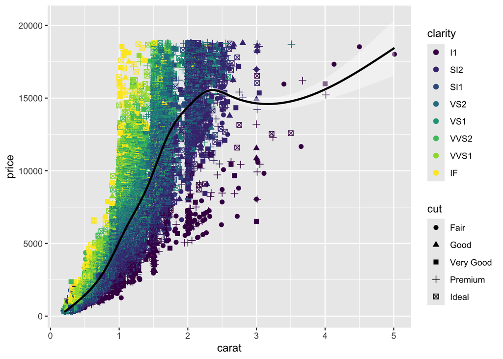

```r
ggplot(data = diamonds, aes(x = carat, y = price)) +
  geom_point(size = 2,
             aes(color = clarity, shape = cut)) +
  geom_smooth(color = "black", fill = "white")
```

Each new layer is added on top of the previous layer - notice how the line covers the points. If we switch the order, we can move layers up or down.

```r
ggplot(data = diamonds, aes(x = carat, y = price)) +
  geom_smooth(color = "black", fill = "white") +
  geom_point(size = 2,
             aes(color = clarity, shape = cut))
```

But its hard to see the line this way, so I think I liked the first order better.

[figure not shown]

## Step 6: Finalize the plot

Now that the plot looks the way we want, we can add some further customization.

Let’s start with 3 things:

- choosing our own aesthetics
- changing the theme.
- adding/changing labels.

### Choosing Our Own Aesthetics

So far we’ve been lettering ggplot choose our colors and shapes. But what if we want to choose our own? Let’s change the shapes that ggplot uses.

```r
ggplot(data = diamonds, aes(x = carat, y = price)) +
  geom_point(size = 2,
             aes(color = clarity, shape = cut)) +
  geom_smooth(color = "black", fill = "white") +
  scale_shape_manual(values = c(1, 2, 3, 4, 5))
```

Notice what I did there. I added to the graph *scale_shape_manual* then provided a vector with the specific shape numbers I wanted. You can do this for ANY AESTHETIC: just add scale_*aesthetic*_manual to your graph and provide a vector with the specific shapes, colors, fills, linetypes, etc. that you want for that aesthetic.

[figure not shown]

### Adding Labels

To add labels, use *labs*, as shown below. There are lots of kinds of labels. The ones you will use most often are:

- *x =* for the x axis label
- *y =* for the y axis label
- *title* for the figure title.

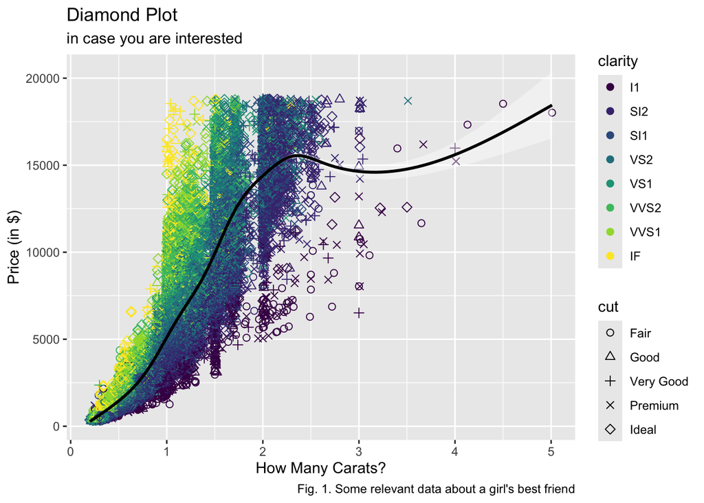

```r
ggplot(data = diamonds, aes(x = carat, y = price)) +
  geom_point(size = 2,
             aes(color = clarity, shape = cut)) +
  geom_smooth(color = "black", fill = "white") +
  scale_shape_manual(values = c(1, 2, 3, 4, 5)) +
  labs(
    title = "Diamond Plot",
    subtitle = "in case you are interested",
    caption =
      "Fig. 1. Some relevant data about a girl\'s best friend",
    x = "How Many Carats?",
    y = "Price (in $)",
    tag = NULL,
    #Useful if your figure is part of a larger multi-panel figure
    alt = "Oops, the plot is missing"
    # Alt text for websites when the plot doesn't load
  )
```

### Changing Themes

You can use prebuilt themes to change to overall appearance of your graph. My favorite is *theme_bw()* which gets rid of that pesky gray background.

*theme()* is quite powerful. You can use this to further customize your graph in almost any way you want, including:

- modifying the plot area
- modifying the axis text, titles, and ticks
- changing font styles and sizes
- modifying the legend’s look, position, side, etc.
- and more!

Here’s a simple example, mostly focused on customizing the legend:

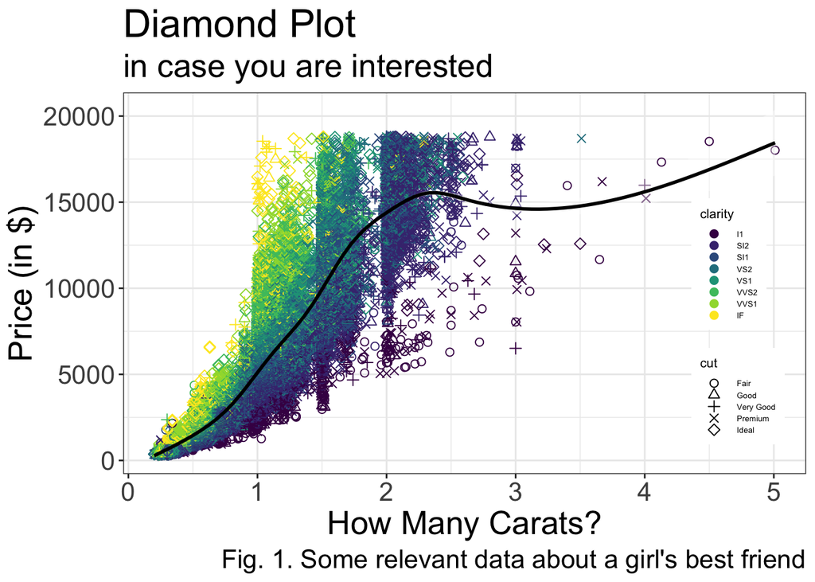

```r
ggplot(data = diamonds, aes(x = carat, y = price)) +
  geom_point(size = 2,
             aes(color = clarity, shape = cut)) +
  geom_smooth(color = "black", fill = "white") +
  scale_shape_manual(values = c(1, 2, 3, 4, 5)) +
  labs(
    title = "Diamond Plot",
    subtitle = "in case you are interested",
    caption =
      "Fig. 1. Some relevant data about a girl\'s best friend",
    x = "How Many Carats?",
    y = "Price (in $)"
  ) + theme_bw() +
  theme(text = element_text(size = 20),
            legend.position = c(0.9, 0.4),
            legend.text = element_text(size = 5),
            legend.title = element_text(size = 8),
            legend.key.height = unit(0.1, "in"))
```

## Step 7: Save the plot

If you’re using R Markdown (and you should be!), then you can *skip* this step - your plots will show up in your document automatically (after you run your code).

But if we wanted to save our beautiful graph to an image file, we would use *ggsave()*.

We can specify the file type (by giving the file name an appropriate extension, like .png) width, height, and dots per inch.

```r
ggsave("MyBeautifulPlot.png", width = 6, height = 4, units = "in", dpi = 300)
```

Before we make a new graph from scratch, let’s practice adjusting the aesthetics on an existing one.

18. Run the code below. Now adjust the code so your graph looks like the one further below.
    - *Note:* The colors I used were red4 and blue4. The fills I used were red1 and blue1. The shapes I used were 21 and 22.
    - Also notice the change in the background color from gray to white.

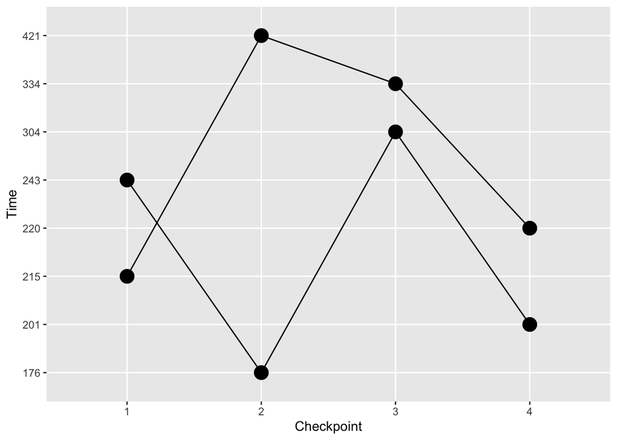

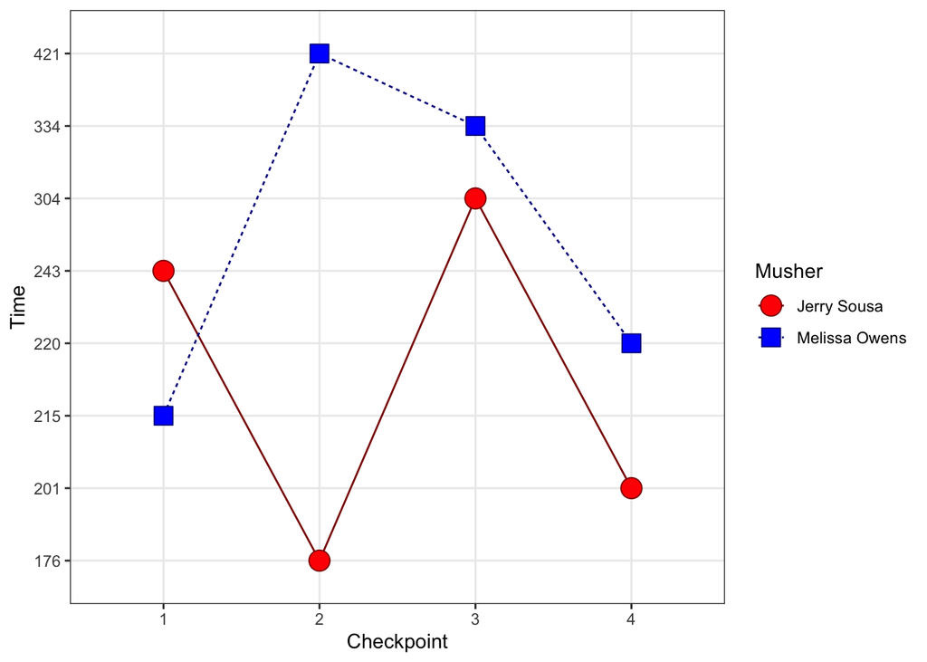

```r
iditaroddata <-  cbind(c(rep("Jerry Sousa", 4), rep("Melissa Owens", 4)), c(1:4, 1:4), c(243,
176,
304,
201,
215,
421,
334,
220
)) %>% data.frame() %>% rename(Musher = X1, Checkpoint = X2, Time = X3)

ggplot(data = iditaroddata, aes(x = Checkpoint, y = Time, group = Musher)) +
          geom_line() +
          geom_point(size = 5)
```

# Color Considerations

When making your graphs, keep the following in mind:

- Not everyone can see all colors
- AND many academic journals don’t print in color
  - Or they make you pay extra!
- SO, make sure your graphs do not *require* color to be interpreted
- This means that you should always have more than one way to differentiate two groups
  - e.g. color and shape/line type

## Color

19. Give 2 reasons that a graph should not rely exclusively on color to show the difference between two groups.
20. What can you do to make sure that your graph is interpretable even without color?

# Making Different Types of Plots

I’ll be using data from the *nycflights13* package for these demos. So, let’s load it.

```r
if (!require("nycflights13")) install.packages("nycflights13")
library(nycflights13)
```

This package includes the *flights* data set, over 336776 flights in and out of NYC in 2013. The date, time, scheduled time, carrier, origin, destination, air time, and distance traveled by each flight are included data points.

You know how to explore a data set by now! Take a moment to look at the *flights* data before moving on.

## Histogram

Let’s start by making a histogram. We’ll look at every air traveler’s worst enemy: departure delays.

### Steps 1-3: Set up the plot area and add a histogram

First we’ll set up ggplot, then add a histogram layer with *geom_histogram()*.

In the code below, notice that *no Y axis is specified*. For histograms (and density plots), only the X axis is needed. The Y axis is computed from the data.

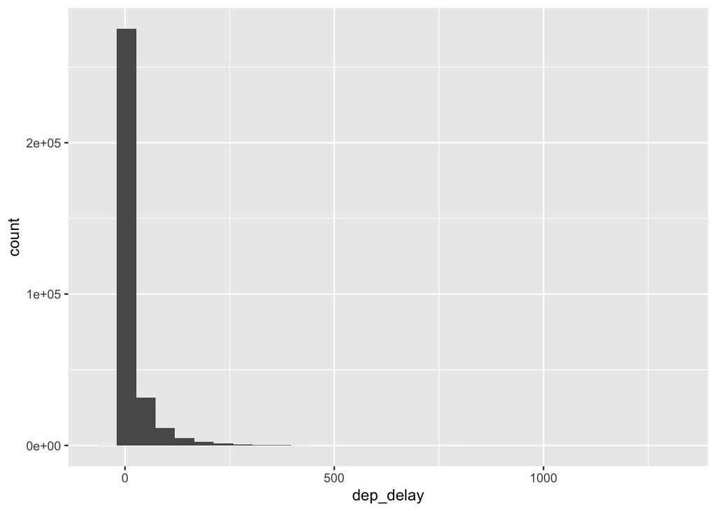

```r
ggplot(data = flights, aes(x = dep_delay)) + geom_histogram()
```